# Homework 4

Tony Daza

2022-10-20

Here we go again. Let the coding begin.

*Note, I accidentally named the project homework 4 instead of lab 4. I am sorry.

Step 1: - Load the required packages

This week we are focusing on data wrangling.

“Dplyr” is the package that we will use for data wrangling functions

“Janitor” helps with cleaning data, it may not be needed, but good to have.

“Tidyverse” includes ggplot2 as well as other packages and functions such as piping that are used throughout the code.

“Here” helps with the initial importing of data.

“Readr” is helpful for reading in data but Rio’s import function is preferred for it’s easy of use to import different types of files.

“Lahman” is a package with the data set we are using with all the baseball teams. The data set is called Teams

```r
library(needs)
needs(tidyverse, dplyr, janitor, here, readr, rio, Lahman)
view(Teams)
```

I am going to use the Minnesota Twins since I moved to Oregon from Minnesota. First, I will create a separate data set with only the twins data for year, wins, losses, runs scored, and runs allowed (Corresponding to name, yearID, W, L, R, RA)

```r
Twins <- Teams %>%
  filter(name == "Minnesota Twins", yearID >= 1980) %>%
  select(name, yearID, W, L, R, RA)
Twins
```

```
##               name yearID   W   L   R  RA
## 1  Minnesota Twins   1980  77  84 670 724
## 2  Minnesota Twins   1981  41  68 378 486
## 3  Minnesota Twins   1982  60 102 657 819
## 4  Minnesota Twins   1983  70  92 709 822
## 5  Minnesota Twins   1984  81  81 673 675
## 6  Minnesota Twins   1985  77  85 705 782
## 7  Minnesota Twins   1986  71  91 741 839
## 8  Minnesota Twins   1987  85  77 786 806
## 9  Minnesota Twins   1988  91  71 759 672
## 10 Minnesota Twins   1989  80  82 740 738
## 11 Minnesota Twins   1990  74  88 666 729
## 12 Minnesota Twins   1991  95  67 776 652
## 13 Minnesota Twins   1992  90  72 747 653
## 14 Minnesota Twins   1993  71  91 693 830
```

[output cut: 28 more lines]

Cool! It worked!

Now we need to create a new variable that is the win percentage for the twins.

If you are a twins fan you may want to skip this section

```r
Twins <- Twins %>%
  mutate(pwin = (W/(W+L))) %>%
  arrange(pwin)
Twins
```

```
##               name yearID   W   L   R  RA      pwin
## 1  Minnesota Twins   2016  59 103 722 889 0.3641975
## 2  Minnesota Twins   1982  60 102 657 819 0.3703704
## 3  Minnesota Twins   1981  41  68 378 486 0.3761468
## 4  Minnesota Twins   1995  56  88 703 889 0.3888889
## 5  Minnesota Twins   2011  63  99 619 804 0.3888889
## 6  Minnesota Twins   1999  63  97 686 845 0.3937500
## 7  Minnesota Twins   2012  66  96 701 832 0.4074074
## 8  Minnesota Twins   2013  66  96 614 788 0.4074074
## 9  Minnesota Twins   1997  68  94 772 861 0.4197531
## 10 Minnesota Twins   2000  69  93 748 880 0.4259259
## 11 Minnesota Twins   1983  70  92 709 822 0.4320988
## 12 Minnesota Twins   1998  70  92 734 818 0.4320988
## 13 Minnesota Twins   2014  70  92 715 777 0.4320988
## 14 Minnesota Twins   1986  71  91 741 839 0.4382716
```

[output cut: 28 more lines]

Above is a list of the record of Twins seasons by year in ascending order by win percentage. 2016 was a rough year.

But let’s look at the bright side and see the best years first by ordering the years in descending order by win percentage.

```r
Twins %>%
  arrange(desc(pwin))
```

```
##               name yearID   W   L   R  RA      pwin
## 1  Minnesota Twins   2019 101  61 939 754 0.6234568
## 2  Minnesota Twins   2020  36  24 269 215 0.6000000
## 3  Minnesota Twins   2006  96  66 801 683 0.5925926
## 4  Minnesota Twins   1991  95  67 776 652 0.5864198
## 5  Minnesota Twins   2002  94  67 768 712 0.5838509
## 6  Minnesota Twins   2010  94  68 781 671 0.5802469
## 7  Minnesota Twins   2004  92  70 780 715 0.5679012
## 8  Minnesota Twins   1988  91  71 759 672 0.5617284
## 9  Minnesota Twins   1992  90  72 747 653 0.5555556
## 10 Minnesota Twins   2003  90  72 801 758 0.5555556
## 11 Minnesota Twins   2008  88  75 829 745 0.5398773
## 12 Minnesota Twins   2009  87  76 817 765 0.5337423
## 13 Minnesota Twins   1987  85  77 786 806 0.5246914
## 14 Minnesota Twins   2001  85  77 771 766 0.5246914
```

[output cut: 28 more lines]

Wow 2019 was a good year for them!

Well that was fun. Let’s see the mean and standard deviation for win percentage

```r
Twins %>%
  summarise(mean(pwin),sd(pwin))
```

```
##   mean(pwin)   sd(pwin)
## 1  0.4849932 0.07140874
```

It appears that the mean win percentage is about 48% with a standard deviation of about 7.14%. I am not sure if that is good or not, but now I know.

That was child’s play. Now we look at the full dataset.

```r
Teams <- Teams %>%
  select(name, yearID, W, L) %>%
  mutate(pwin = (W/(W+L))) %>%
  arrange(desc(pwin))



head(Teams, n = 10)
```

```
##                       name yearID   W  L      pwin
## 1     Boston Red Stockings   1875  71  8 0.8987342
## 2        St. Louis Maroons   1884  94 19 0.8318584
## 3     Boston Red Stockings   1872  39  8 0.8297872
## 4  Chicago White Stockings   1880  67 17 0.7976190
## 5  Chicago White Stockings   1876  52 14 0.7878788
## 6  Chicago White Stockings   1885  87 25 0.7767857
## 7             Chicago Cubs   1906 116 36 0.7631579
## 8          New York Giants   1885  85 27 0.7589286
## 9   Philadelphia Athletics   1871  21  7 0.7500000
## 10        Providence Grays   1884  84 28 0.7500000
```

Above you can see the top ten seasons by win percentage over the years.

1875 was an unforgettable year for the Boston Red Stockings.

Finally, to round out our baseball data. Below you will find a graph of the Detroit Tigers, The New York Yankees, and the San Diego Padres win percentage over the years.

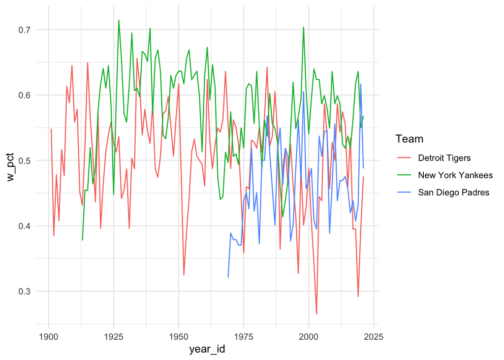

```r
team_graph <- Teams %>%
  filter(name == "Detroit Tigers" | name == "New York Yankees" | name == "San Diego Padres", yearID >= 1900) %>%
  select(name, yearID, pwin) %>%
  ggplot(aes(x = yearID, y = pwin)) +
  geom_line(aes(color = name))+
  theme_minimal() +
  labs(x = "year_id", y = "w_pct", color = "Team")
team_graph
```

*This does look slightly different than the example as there is an extra year or two of more recent data. I can remove those data points if needed

I hope you enjoyed our dive into baseball. We will now move on to talking about red blood cell counts and sports

```r
needs(readxl, readr)
ais <- read_excel(here("~/Desktop/Homework 4/data/ais.xlsx"), skip = 15)
head(ais)
```

```
## # A tibble: 6 × 13
##     rcc   wcc    hc    hg  ferr   bmi   ssf pcBfat   lbm    ht    wt sex   sport
##   <dbl> <dbl> <dbl> <dbl> <dbl> <dbl> <dbl>  <dbl> <dbl> <dbl> <dbl> <chr> <chr>
## 1  3.96   7.5  37.5  12.3    60  20.6 109.    19.8  63.3  196.  78.9 f     B_Ba…
## 2  4.41   8.3  38.2  12.7    68  20.7 103.    21.3  58.6  190.  74.4 f     B_Ba…
## 3  4.14   5    36.4  11.6    21  21.9 105.    19.9  55.4  178.  69.1 f     B_Ba…
## 4  4.11   5.3  37.3  12.6    69  21.9 126.    23.7  57.2  185   74.9 f     B_Ba…
## 5  4.45   6.8  41.5  14      29  19.0  80.3   17.6  53.2  185.  64.6 f     B_Ba…
## 6  4.1    4.4  37.4  12.5    42  21.0  75.2   15.6  53.8  174   63.7 f     B_Ba…
```

Above is a peak at the AIS data set.We will come back to this one in a second.

```r
star <- import(here("~/Desktop/Homework 4/data/star.csv"))
head(star, n = 10)
```

```
##    schidkn  sex frl reg_size reg_size_aid small_size white black other totexp
## 1       63 girl  no        0            0          1     1     0     0      7
## 2       20 girl  no        0            0          1     0     1     0     21
## 3       19  boy yes        0            1          0     0     1     0      0
## 4       69  boy  no        1            0          0     1     0     0     16
## 5       79  boy yes        0            0          1     1     0     0      5
## 6        5  boy yes        1            0          0     1     0     0      8
## 7       16 girl yes        0            1          0     0     1     0     17
## 8       56 girl  no        1            0          0     1     0     0      3
## 9       11 girl  no        0            0          1     0     1     0     11
## 10      66 girl  no        0            0          1     1     0     0     10
##    tmathss treadss
## 1      473     447
## 2      536     450
## 3      463     439
## 4      559     448
## 5      489     447
## 6      454     431
## 7      423     395
## 8      500     451
## 9      439     478
## 10     528     455
```

Here is a look at the Star Data set

```r
sesame_st <- import(here("~/Desktop/Homework 4/data/sesame13.sav")) %>%
  janitor::clean_names()
head(sesame_st, n = 10)
```

```
##    id site sex age viewing setting treatmen prebody prelet preform prenumb
## 1   1    1   1  66       1       1        1      16     23      12      40
## 2   2    1   2  67       3       1        1      30     26       9      39
## 3   3    1   1  56       3       1        0      22     14       9       9
## 4   4    1   1  49       1       1        0      23     11      10      14
## 5   5    1   1  69       4       1        0      32     47      15      51
## 6   6    1   2  54       3       1        0      29     26      10      33
## 7   7    1   2  47       3       1        0      23     12      11      13
## 8   8    1   1  51       2       1        1      32     48      19      52
## 9   9    1   1  69       4       1        1      27     44      18      42
## 10 10    1   2  53       3       1        1      30     38      17      31
##    prerelat preclass postbody postlet postform postnumb postrel postclas ppvt
## 1        14       20       18      30       14       44      14       23   62
## 2        16       22       30      37       17       39      14       22   80
## 3         9        8       21      46       15       40       9       19   32
## 4         9       13       21      14       13       19       8       15   27
## 5        17       22       32      53       18       54      14       21   71
## 6        14       14       27      36       14       39      16       24   32
## 7        11       12       22      45       12       44      12       15   28
## 8        15       23       31      47       18       51      17       23   38
## 9        15       20       32      50       17       48      14       24   49
## 10       10       17       32      52       19       52      17       24   32
```

Finally above is a peak at the sesame 13 data set.

And now back to the blood cells. Below is the average red blood cell count and average BMI by sport.

```r
AIS <- ais %>%
  select(rcc, bmi, sport) %>%
  group_by(sport) %>%
  summarise(avg_rcc = mean(rcc),
            avg_bmi = mean(bmi))
AIS
```

```
## # A tibble: 10 × 3
##    sport   avg_rcc avg_bmi
##    <chr>     <dbl>   <dbl>
##  1 B_Ball     4.57    22.3
##  2 Field      5.02    27.5
##  3 Gym        4.31    18.5
##  4 Netball    4.23    22.4
##  5 Row        4.68    23.5
##  6 Swim       4.71    22.9
##  7 T_400m     4.69    20.7
##  8 T_Sprnt    5.19    22.9
##  9 Tennis     4.79    21.1
## 10 W_Polo     5.03    24.5
```

```r
export(AIS, "AIS_sport.xlsx")

export(AIS, "AIS_sport.sav")
```

```r
sesame_st %>%
  characterize("setting") %>%
  group_by(setting) %>%
  summarise(mean_age = mean(age))
```

```
## # A tibble: 2 × 2
##   setting mean_age
##   <chr>      <dbl>
## 1 Home        50.2
## 2 School      53.5
```

The home group had a lower average age in months compared to the school group.

Finally let’s look at the Star data First we will look at the data using str() which will tell us that there are 12 variables (columns) and 5748 observations (rows)

```r
needs(psych)
str(star)
```

```
## 'data.frame':    5748 obs. of  12 variables:
##  $ schidkn     : int  63 20 19 69 79 5 16 56 11 66 ...
##  $ sex         : chr  "girl" "girl" "boy" "boy" ...
##  $ frl         : chr  "no" "no" "yes" "no" ...
##  $ reg_size    : int  0 0 0 1 0 1 0 1 0 0 ...
##  $ reg_size_aid: int  0 0 1 0 0 0 1 0 0 0 ...
##  $ small_size  : int  1 1 0 0 1 0 0 0 1 1 ...
##  $ white       : int  1 0 0 1 1 1 0 1 0 1 ...
##  $ black       : int  0 1 1 0 0 0 1 0 1 0 ...
##  $ other       : int  0 0 0 0 0 0 0 0 0 0 ...
##  $ totexp      : int  7 21 0 16 5 8 17 3 11 10 ...
##  $ tmathss     : int  473 536 463 559 489 454 423 500 439 528 ...
##  $ treadss     : int  447 450 439 448 447 431 395 451 478 455 ...
```

But personally I like the describe function from the psych package because it also gives the standard deviation and mean plus some other descriptive statistics.

```r
describe(star)
```

```
##              vars    n   mean    sd median trimmed   mad min max range  skew
## schidkn         1 5748  39.84 22.96     39   39.76 29.65   1  80    79  0.04
## sex*            2 5748   1.49  0.50      1    1.48  0.00   1   2     1  0.06
## frl*            3 5748   1.48  0.50      1    1.48  0.00   1   2     1  0.07
## reg_size        4 5748   0.35  0.48      0    0.31  0.00   0   1     1  0.64
## reg_size_aid    5 5748   0.35  0.48      0    0.31  0.00   0   1     1  0.63
## small_size      6 5748   0.30  0.46      0    0.25  0.00   0   1     1  0.86
## white           7 5748   0.67  0.47      1    0.72  0.00   0   1     1 -0.74
## black           8 5748   0.32  0.47      0    0.28  0.00   0   1     1  0.76
## other           9 5748   0.00  0.07      0    0.00  0.00   0   1     1 14.48
## totexp         10 5748   9.31  5.77      9    9.00  5.93   0  27    27  0.42
## tmathss        11 5748 485.65 47.77    484  483.20 44.48 320 626   306  0.47
## treadss        12 5748 436.74 31.77    433  433.80 28.17 315 627   312  1.34
##              kurtosis   se
## schidkn         -1.23 0.30
## sex*            -2.00 0.01
## frl*            -2.00 0.01
## reg_size        -1.59 0.01
## reg_size_aid    -1.61 0.01
## small_size      -1.25 0.01
## white           -1.46 0.01
## black           -1.42 0.01
## other          207.82 0.00
## totexp          -0.21 0.08
## tmathss          0.29 0.63
## treadss          3.83 0.42
```

The next step is to remove the outliers in this case data that is 3 standard deviations above or below the mean

```r
star %>%
  characterize() %>%
  select(tmathss) %>%
  mutate(lower = (mean(tmathss) - sd(tmathss, na.rm = TRUE)*3)) %>%
  arrange(tmathss) %>%
  head(star, n = 5)
```

```
##   tmathss    lower
## 1     320 342.3335
## 2     320 342.3335
## 3     339 342.3335
## 4     339 342.3335
## 5     339 342.3335
```

```r
star %>%
  characterize() %>%
  select(tmathss) %>%
  mutate(upper = (mean(tmathss) + sd(tmathss, na.rm = TRUE)*3)) %>%
  arrange(desc(tmathss)) %>%
  head(star, n = 5)
```

```
##   tmathss    upper
## 1     626 628.9626
## 2     626 628.9626
## 3     626 628.9626
## 4     626 628.9626
## 5     626 628.9626
```

These pieces show the lowest 5 and highest 5 scores as well as the cut off for 3 standard deviations above or below the mean.

```r
star %>%
  summarise(sd_low = (mean(tmathss) - (sd(tmathss)*3)),
         sd_high = (mean(tmathss) + (sd(tmathss*3))))
```

```
##     sd_low  sd_high
## 1 342.3335 628.9626
```

Here we can see the cut offs for the scores

```r
star_norm <- star %>%
  filter(tmathss < 628.9626,
         tmathss > 342.3335)
head(star_norm)
```

```
##   schidkn  sex frl reg_size reg_size_aid small_size white black other totexp
## 1      63 girl  no        0            0          1     1     0     0      7
## 2      20 girl  no        0            0          1     0     1     0     21
## 3      19  boy yes        0            1          0     0     1     0      0
## 4      69  boy  no        1            0          0     1     0     0     16
## 5      79  boy yes        0            0          1     1     0     0      5
## 6       5  boy yes        1            0          0     1     0     0      8
##   tmathss treadss
## 1     473     447
## 2     536     450
## 3     463     439
## 4     559     448
## 5     489     447
## 6     454     431
```

That was a bit more challenging, but after some computations the values for 3 standard deviations above for the math score was 628.96 and 3 standard deviations below for math score was 342.

After filtering for outliers, 5 observations were removed from the lower end of the data set.

Now for the more challenging part. I will standardized the math and reading scores.

```r
star_stand <- star %>%
  select(tmathss, treadss) %>%
  mutate(tmathss = (tmathss - mean(tmathss))/sd(tmathss),
         treadss = (treadss - mean(treadss))/sd(treadss))
head(star_stand)
```

```
##       tmathss     treadss
## 1 -0.26476127  0.32284333
## 2  1.05401580  0.41726354
## 3 -0.47409097  0.07105609
## 4  1.53547409  0.35431673
## 5  0.07016624  0.32284333
## 6 -0.66248769 -0.18073116
```

```r
star_stand_means <- star_stand %>%
  summarise(mean(tmathss),
            sd(tmathss),
            mean(treadss),
            sd(treadss)) %>%
  round(digits = 3)
star_stand_means
```

```
##   mean(tmathss) sd(tmathss) mean(treadss) sd(treadss)
## 1             0           1             0           1
```

Looks like it worked though there was a rounding error that prevented the mean from showing as zero, but the means of the standardized scores are essentially zero and with a little rounding it shows as zero.

```r
star_stand <- star %>%
  select(tmathss, treadss, sex, frl) %>%
  mutate(tmathss = (tmathss - mean(tmathss))/sd(tmathss),
         treadss = (treadss - mean(treadss))/sd(treadss))

star_stand_means_sex_frl <- star_stand %>%
  characterize() %>%
  group_by(sex, frl) %>%
  summarise(mean(tmathss),
            sd(tmathss),
            mean(treadss),
            sd(treadss))
```

[output not shown]

```r
star_stand_means_sex_frl
```

```
## # A tibble: 4 × 6
## # Groups:   sex [2]
##   sex   frl   `mean(tmathss)` `sd(tmathss)` `mean(treadss)` `sd(treadss)`
##   <chr> <chr>           <dbl>         <dbl>           <dbl>         <dbl>
## 1 boy   no              0.151         0.970           0.148         1.02
## 2 boy   yes            -0.330         0.965          -0.358         0.838
## 3 girl  no              0.326         0.962           0.371         1.09
## 4 girl  yes            -0.170         0.969          -0.187         0.863
```

Above is a summary of the mean and sd of the standardized math and reading scores by sex and free and reduced price lunch status.

Based on this it looks like boys who do not receive frp lunch had math and read scores higher than boys who did receive frp lunch.

The difference was even more pronounced for girls who received frp lunch and girls who did not. With girls without frp lunch having higher math and reading scores on average.

There appears to be an interaction by gender with frl status being larger for girls than boys but I am not sure if it is significant without running further analyses.

At this point you can stop reading but I am curious if I can try to examine the data a little further.

```r
needs(MBESS, lm.beta)
cor(x = star_stand$tmathss, y = star_stand$treadss)
```

```
## [1] 0.7135489
```

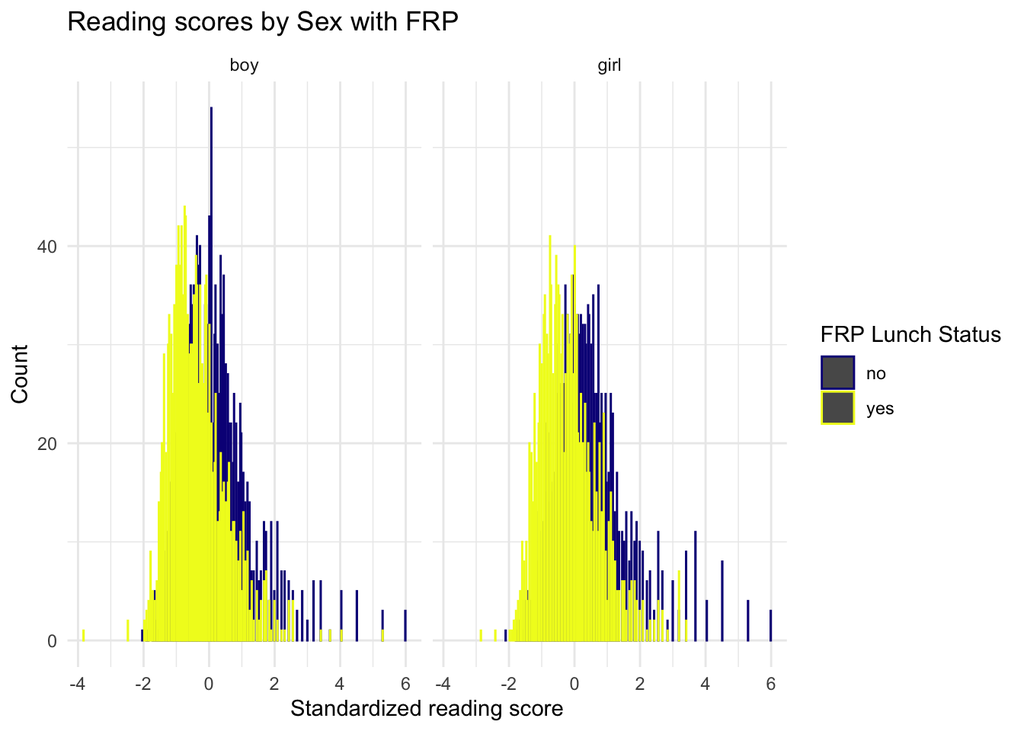

```r
#Correlation between math and reading scores is 0.71 which is expected that they are strongly correlated in a positive direction

star_stand %>%
  ggplot(aes(x = treadss, color = frl)) +
  geom_bar(position = "dodge") +
  facet_wrap(~sex)+
  theme_minimal()+
  labs(title = "Reading scores by Sex with FRP", x= "Standardized reading score", y = "Count", color = "FRP Lunch Status")+
  scale_color_viridis_d(option = "plasma")
```

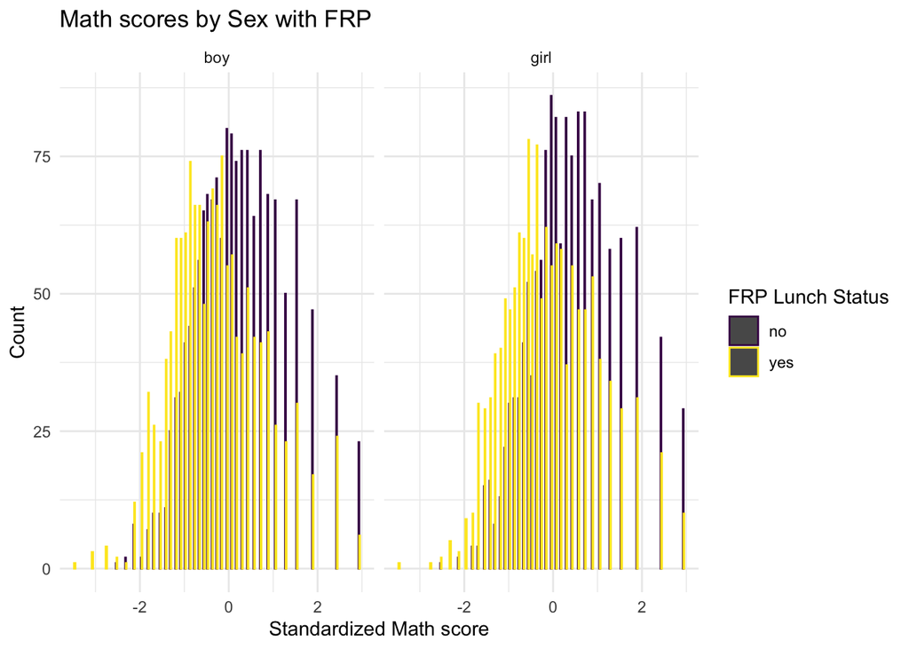

```r
#Standardized Reading scores by FRP Lunch status and sex distribution

star_stand %>%
  ggplot(aes(x = tmathss, color = frl)) +
  geom_bar(position = "dodge") +
  facet_wrap(~sex)+
  theme_minimal()+
  labs(title = "Math scores by Sex with FRP", x= "Standardized Math score", y = "Count", color = "FRP Lunch Status")+
  scale_color_viridis_d()
```

```r
#Standardized Math scores by FRP Lunch Status and sex distribution
```

It is clear from these graphs that there is a difference between the distributions of reading and math scores for students receiving FRP lunch and a smaller differences between boys and girls.

Perhaps if I have more time I will examine the exact differences.